# Homework 4

Lauren Smith

08 October 2019

# Exercise 1

*Univartiate Option 1*

*1. Make a tibble with one row per year, and columns for life expectancy for two or more countries.* *2. Take advantage of this new data shape to scatterplot life expectancy for one country against that of another.* *3. Re-lengthen the data.*

**First, I widened the data using pivot_wider:**

|  | year | Canada | Norway |
| --- | --- | --- | --- |
| 1 | 1952 | 68.75 | 72.67 |
| 2 | 1957 | 69.96 | 73.44 |
| 3 | 1962 | 71.3 | 73.47 |
| 4 | 1967 | 72.13 | 74.08 |
| 5 | 1972 | 72.88 | 74.34 |
| 6 | 1977 | 74.21 | 75.37 |
| 7 | 1982 | 75.76 | 75.97 |
| 8 | 1987 | 76.86 | 75.89 |
| 9 | 1992 | 77.95 | 77.32 |
| 10 | 1997 | 78.61 | 78.32 |

[output cut: 2 more lines]

Next, I’ll show a quick plot of life expectancy in Canada and Norway.

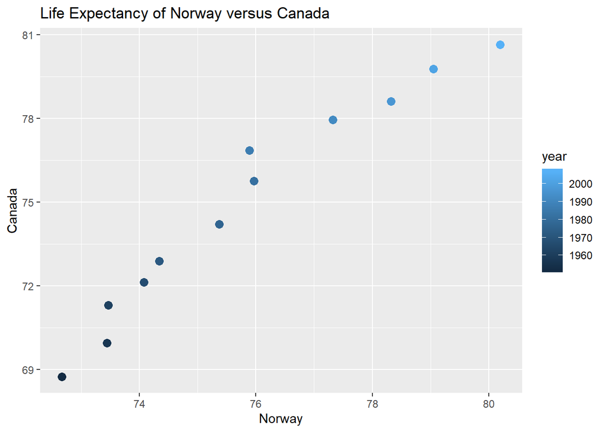

```r
gap_wide %>%
  ggplot(aes(Norway, Canada, fill = year, color = year)) +
  geom_point(size = 3) +
  labs(title = "Life Expectancy of Norway versus Canada")
```

**This plot shows the life expectancy for Norway (x-axis) and Canada (y-axis) between 1952 and 2007. I don’t think having the data in this wider format is the best way to format the data in order to plot it efficiently.**

**Lastly, I restore the data to the previous columns, which is better for plotting the data effectively.**

```r
gap_long <- gap_wide %>%
  pivot_longer(cols = c(Canada, Norway),
               names_to = "country",
               values_to = "lifeExp") %>%
  arrange(country)
gap_long %>%
  datatable()
```

|  | year | country | lifeExp |
| --- | --- | --- | --- |
| 1 | 1952 | Canada | 68.75 |
| 2 | 1957 | Canada | 69.96 |
| 3 | 1962 | Canada | 71.3 |
| 4 | 1967 | Canada | 72.13 |
| 5 | 1972 | Canada | 72.88 |
| 6 | 1977 | Canada | 74.21 |
| 7 | 1982 | Canada | 75.76 |
| 8 | 1987 | Canada | 76.86 |
| 9 | 1992 | Canada | 77.95 |
| 10 | 1997 | Canada | 78.61 |

[output cut: 14 more lines]

**In this format, it will be much easier to display the data efficiently.See below for a plot that is easier to interpret.**

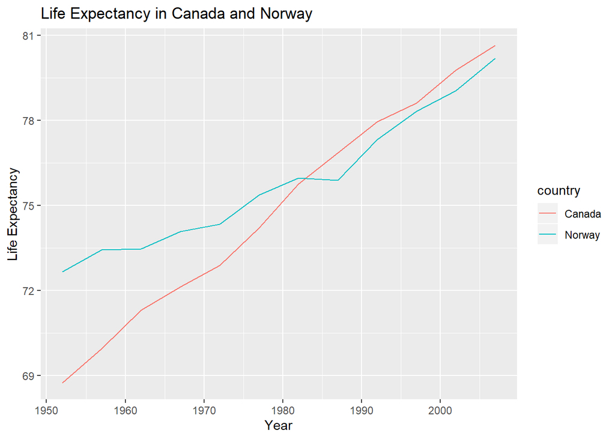

```r
gap_long %>%
  ggplot(aes(year, lifeExp, group = country)) +
  geom_line(aes(color = country)) +
  labs(title = "Life Expectancy in Canada and Norway", x = "Year", y = "Life Expectancy")
```

# Exercise 2

*Multivariate Option 1*

*1. Make a tibble with one row per year, and columns for life expectancy and GDP per capita (or two other numeric variables) for two of more countries* *2. Re-lengthen the data.*

**First, I widen the data using pivot_wider, and in this case the two numerical variables are life expectancy and GDP per capita.**

```r
gap_multi_wide <- gapminder %>%
  select(country, year, lifeExp, gdpPercap) %>%
  filter(country == "Canada" | country == "Norway") %>%
  pivot_wider(id_cols = year,
              names_from = country,
              names_sep = "_",
              values_from = c(lifeExp, gdpPercap))
gap_multi_wide %>%
  datatable()
```

|  | year | lifeExp_Canada | lifeExp_Norway | gdpPercap_Canada | gdpPercap_Norway |
| --- | --- | --- | --- | --- | --- |
| 1 | 1952 | 68.75 | 72.67 | 11367.16112 | 10095.42172 |
| 2 | 1957 | 69.96 | 73.44 | 12489.95006 | 11653.97304 |
| 3 | 1962 | 71.3 | 73.47 | 13462.48555 | 13450.40151 |
| 4 | 1967 | 72.13 | 74.08 | 16076.58803 | 16361.87647 |
| 5 | 1972 | 72.88 | 74.34 | 18970.57086 | 18965.05551 |
| 6 | 1977 | 74.21 | 75.37 | 22090.88306 | 23311.34939 |
| 7 | 1982 | 75.76 | 75.97 | 22898.79214 | 26298.63531 |
| 8 | 1987 | 76.86 | 75.89 | 26626.51503 | 31540.9748 |
| 9 | 1992 | 77.95 | 77.32 | 26342.88426 | 33965.66115 |
| 10 | 1997 | 78.61 | 78.32 | 28954.92589 | 41283.16433 |

[output cut: 2 more lines]

**Then, I relengthen the data to show life expectancy and GDP per capita in individual columns again.**

```r
gap_multi_long <- gap_multi_wide %>%
  pivot_longer(cols = c(lifeExp_Canada, lifeExp_Norway, gdpPercap_Canada, gdpPercap_Norway),
               names_to = c(".value", "country"),
               names_sep = "_",
               values_to = c(lifeExp, gdpPercap)) %>%
  arrange(country)
gap_multi_long %>%
  datatable()
```

|  | year | country | lifeExp | gdpPercap |
| --- | --- | --- | --- | --- |
| 1 | 1952 | Canada | 68.75 | 11367.16112 |
| 2 | 1957 | Canada | 69.96 | 12489.95006 |
| 3 | 1962 | Canada | 71.3 | 13462.48555 |
| 4 | 1967 | Canada | 72.13 | 16076.58803 |
| 5 | 1972 | Canada | 72.88 | 18970.57086 |
| 6 | 1977 | Canada | 74.21 | 22090.88306 |
| 7 | 1982 | Canada | 75.76 | 22898.79214 |
| 8 | 1987 | Canada | 76.86 | 26626.51503 |
| 9 | 1992 | Canada | 77.95 | 26342.88426 |
| 10 | 1997 | Canada | 78.61 | 28954.92589 |

[output cut: 14 more lines]

# Exercise 3

## 3.1

*For each guest in the guestlist (guest tibble), add a column for email address, which can be found in the email tibble.*

**First, I wanted to separate the guests from each family in email - now email, matches the format of the “guest”. Then I renamed the “guest” column in email to “name” so that it also matches guest.**

**Next, I used left_join to add the emails for each person. *note/question: why does it need to be “c(”name“)” in the left_join function? Why didn’t just “name” work (only added email for one person in each party)?**

**Lastly, I selected for party, name, and email to make the tibble easier to look at.**

```r
email_sep <-
  email %>%
  separate_rows(guest, sep = ", ") %>%
  rename(name = guest)

guest2 <- guest %>%
  left_join(email_sep, by = c("name")) %>%
  select(party, name, email)
guest2 %>%
  datatable()
```

|  | party | name | email |
| --- | --- | --- | --- |
| 1 | 1 | Sommer Medrano | sommm@gmail.com |
| 2 | 1 | Phillip Medrano | sommm@gmail.com |
| 3 | 1 | Blanka Medrano | sommm@gmail.com |
| 4 | 1 | Emaan Medrano | sommm@gmail.com |
| 5 | 2 | Blair Park | bpark@gmail.com |
| 6 | 2 | Nigel Webb | bpark@gmail.com |
| 7 | 3 | Sinead English | singlish@hotmail.ca |
| 8 | 4 | Ayra Marks | marksa42@gmail.com |
| 9 | 5 | Atlanta Connolly |  |
| 10 | 5 | Denzel Connolly |  |

[output cut: 20 more lines]

## 3.2

*Who do we have emails for, yet are not on the guestlist?*

**I used anti_join to find the people in the email file who were not included in the guest file.**

```r
email_sep %>%
  anti_join(guest, by = c("name")) %>%
  datatable()
```

|  | name | email |
| --- | --- | --- |
| 1 | Turner Jones | tjjones12@hotmail.ca |
| 2 | Albert Marshall | themarshallfamily1234@gmail.com |
| 3 | Vivian Marshall | themarshallfamily1234@gmail.com |

## 3.3

*Make a guestlist that includes everyone we have emails for (in addition to those on the original guestlist).*

**I used full_join to create a tibble that includes all of the guests in the original guestlist in addition to the three people that were in the email list but not the original guest list.**

```r
guest_list <- guest %>%
  full_join(email_sep, by = c("name"))
guest_list %>%
  datatable()
```

|  | party | name | meal_wedding | meal_brunch | attendance_wedding | attendance_brunch | attendance_golf | email |
| --- | --- | --- | --- | --- | --- | --- | --- | --- |
| 1 | 1 | Sommer Medrano | PENDING | PENDING | PENDING | PENDING | PENDING | sommm@gmail.com |
| 2 | 1 | Phillip Medrano | vegetarian | Menu C | CONFIRMED | CONFIRMED | CONFIRMED | sommm@gmail.com |
| 3 | 1 | Blanka Medrano | chicken | Menu A | CONFIRMED | CONFIRMED | CONFIRMED | sommm@gmail.com |
| 4 | 1 | Emaan Medrano | PENDING | PENDING | PENDING | PENDING | PENDING | sommm@gmail.com |
| 5 | 2 | Blair Park | chicken | Menu C | CONFIRMED | CONFIRMED | CONFIRMED | bpark@gmail.com |
| 6 | 2 | Nigel Webb |  |  | CANCELLED | CANCELLED | CANCELLED | bpark@gmail.com |
| 7 | 3 | Sinead English | PENDING | PENDING | PENDING | PENDING | PENDING | singlish@hotmail.ca |
| 8 | 4 | Ayra Marks | vegetarian | Menu B | PENDING | PENDING | PENDING | marksa42@gmail.com |
| 9 | 5 | Atlanta Connolly | PENDING | PENDING | PENDING | PENDING | PENDING |  |
| 10 | 5 | Denzel Connolly | fish | Menu B | CONFIRMED | CONFIRMED | CONFIRMED |  |

[output cut: 23 more lines]